# 🪙📊 Case Study: Bitcoin Price Forecasting & Crypto btc Market Influence Analysis

-- chinmay palshetkar

#### 🧠🎯 Project Objective :-

##### 1) to investigate the interdependencies between BTC and major altcoins: Ethereum (ETH), Solana (SOL), BNB, Cardano (ADA), and XRP.

##### 2)To analyze and forecast the price of Bitcoin (BTC) using advanced time series models—ARIMA, Facebook Prophet, and LSTM

#### 💡 Why This Project?

##### Cryptocurrencies remain highly volatile and are influenced by complex market dynamics. Understanding Bitcoin’s influence on other coins can help traders, investors, and financial analysts make better data-driven decisions. The project also demonstrates real-world time series forecasting, valuable in fintech and quantitative roles.

#### 🛠️ Tools & Technologies

##### Languages: Python (Pandas, NumPy, Matplotlib,seaborn)

##### Libraries: yfinance, statsmodels, fbprophet, tensorflow.keras, sklearn

##### Models: ARIMA, Facebook Prophet, LSTM

##### Evaluation Metrics: RMSE, MAE

##### Notebook Environment: Jupyter Notebook , Vs Code

### 🔍 Exploratory Data Analysis (EDA)

#### Visualized BTC price trends and compared them to altcoins - ETH, SOL, BNB, ADA, and XRP using overlay line charts.

##### Does Bitcoin dominance influence the price movement of major altcoins in the cryptocurrency market?

Answer - Yes ,

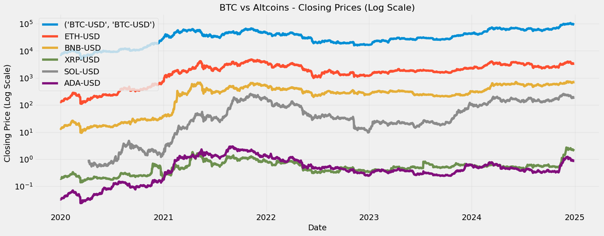

Used correlation matrices and heatmaps to identify high positive correlation between BTC and the rest of the altcoins. -

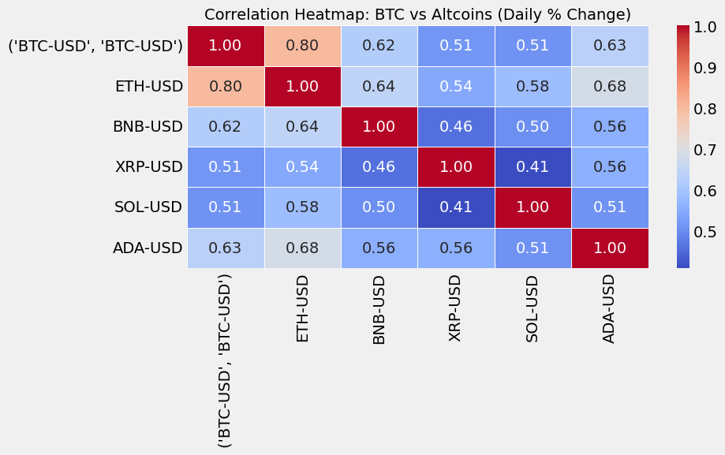

#### 📌 Conclusion:

##### Does Bitcoin dominance influence the price movement of major altcoins in the cryptocurrency market?

##### ✅ Influence of Bitcoin on Altcoins :

Bitcoin Dominance: The analysis supports the hypothesis that Bitcoin (BTC) plays a dominant role in influencing the price movements of major altcoins in the crypto market.

High Correlation with ETH: The strongest correlation is observed between BTC and ETH (0.80), indicating that Ethereum closely follows Bitcoin's price trends.

Moderate Influence on Other Altcoins: BTC shows moderate correlation with BNB (0.62), SOL (0.51), ADA (0.63), and XRP (0.51). While not as strong as BTC–ETH, these correlations still suggest partial dependence on BTC's movement.

Log-Scale Trends: The log-scale price chart shows that most altcoins mimic BTC's overall growth trajectory, especially during major market rallies or crashes, supporting the idea of market-wide sentiment being led by BTC.

##### 🔍 Insight:

These findings confirm that BTC remains the primary market mover. Even when altcoins have unique ecosystems, technological use cases, or community dynamics, their short-term price behavior is still heavily influenced by Bitcoin.

## 📈 Exploratory Highlights:

##### 🧠 Conclusion: Altcoins don’t just follow trends—they follow Bitcoin.

## Closing Price Of bitcoin over the Time

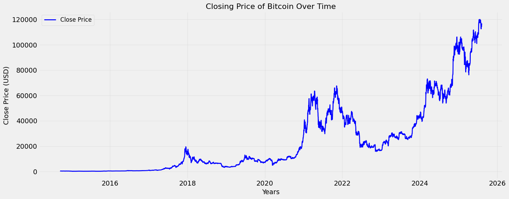

# 💹📈📉🧪 Forecasting Models :-

#### 1️⃣ ARIMA (AutoRegressive Integrated Moving Average)

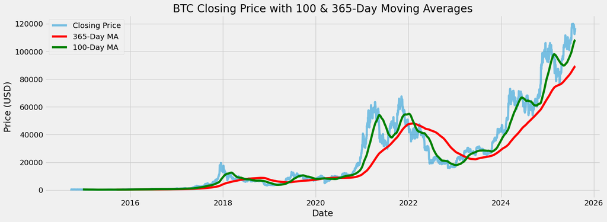

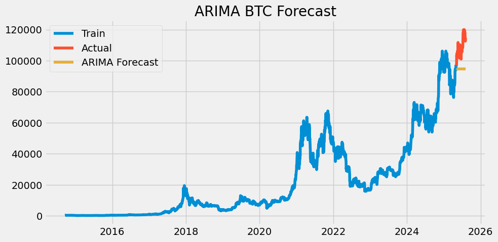

RMSE: 15634.40 MAE: 14515.04

### 🔍 Short Observation – ARIMA Forecast Evaluation

- RMSE: 15,634 → High error, sensitive to large BTC price swings.
- MAE: 14,515 → Average prediction error, shows consistent deviation.

#### 📌 Insight:

ARIMA shows poor/moderate accuracy on BTC price forecasting, with notable error margins, likely due to high volatility in crypto markets. Use as a baseline model for comparison with Prophet or LSTM.

- Captures linear temporal dependencies.
- Basic, interpretable model but less effective with crypto volatility.

## 2️⃣ Facebook Prophet forcasting :-

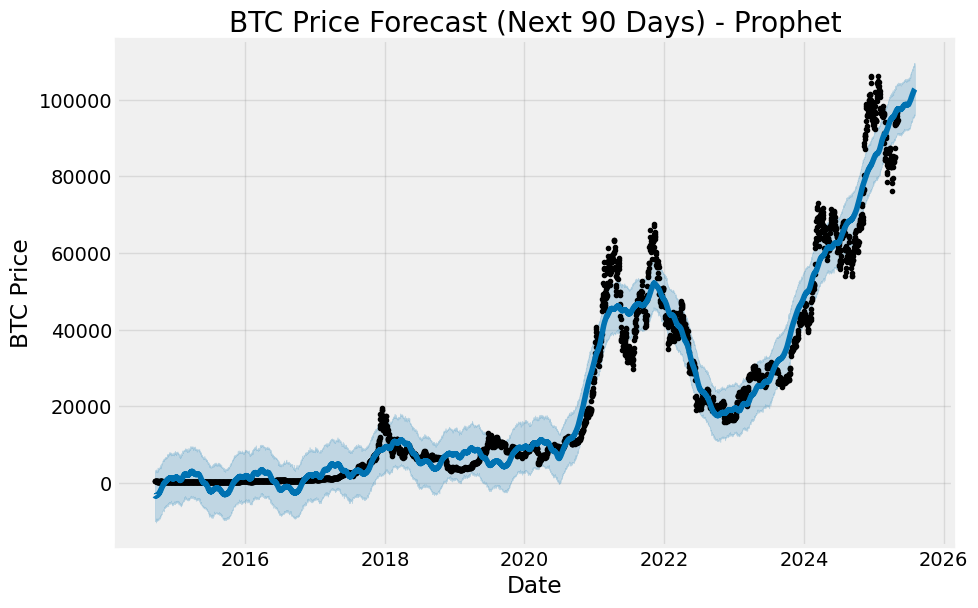

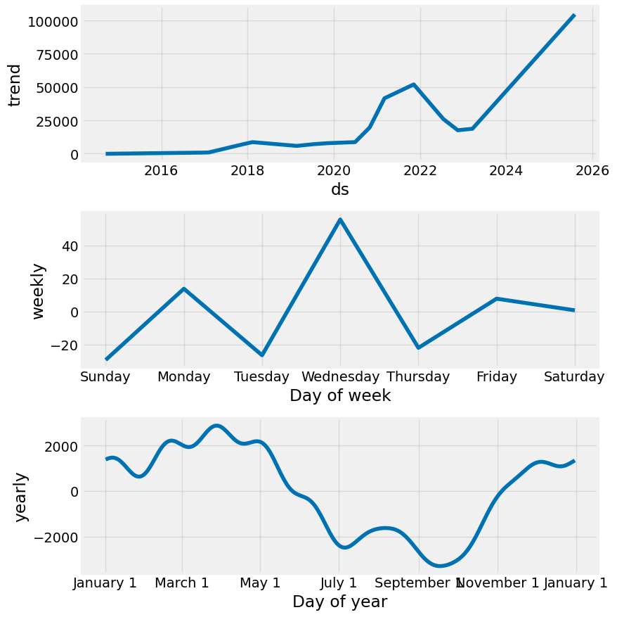

RMSE: 11062.15 MAE: 10075.08

### 🔍 Short Observation – Facebook Prophet Forecast Evaluation :

- RMSE: 11,062.15 → On average,predicted BTC prices deviate by around $11,062 from actual values, with more sensitivity to large errors.
- MAE: 10,075.08 → The average absolute difference between predicted and actual BTC prices is $10,075, regardless of direction (over or under).
- 📉 Interpretation: Prophet has performed better than earlier ARIMA model (RMSE ~15,634, MAE ~14,515), indicating improved prediction accuracy.

#### 📈 Plot Interpretation

- Forecast Plot (First Image):
- Blue line: Predicted BTC prices (yhat).
- Shaded region: Uncertainty interval.
- Shows an upward trend into the future with widening uncertainty.
- Trend + Seasonality Plots (Second Image):
- Trend (top): Long-term BTC price increase.
- Weekly seasonality (middle): Peaks on Wednesdays, dips on Tuesdays & Sundays.
- Yearly seasonality (bottom): BTC tends to peak around March–April, and dip during July–September.
- Captures trend, seasonality, and holiday effects.
- Generates confidence intervals for better business interpretability.

## 3️⃣ LSTM (Long Short-Term Memory Neural Network) Forcating :

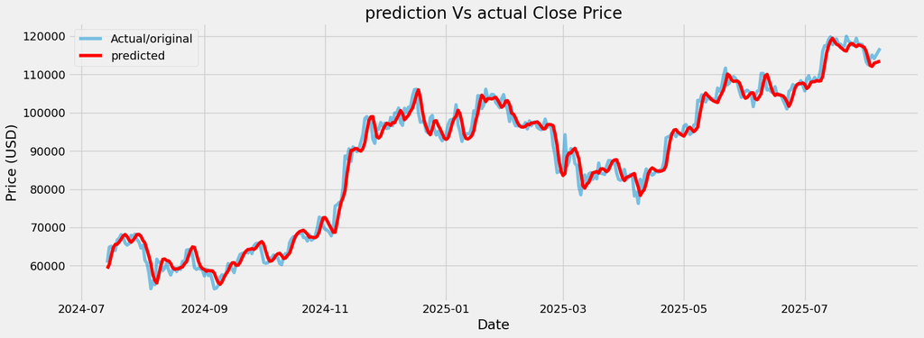

LSTM Test Prediction - RMSE: 2522.85

LSTM Test Prediction - MAE: 1909.45

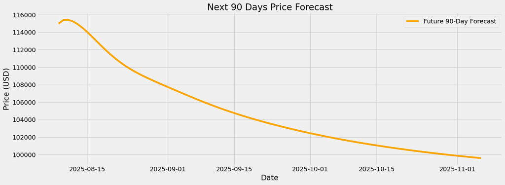

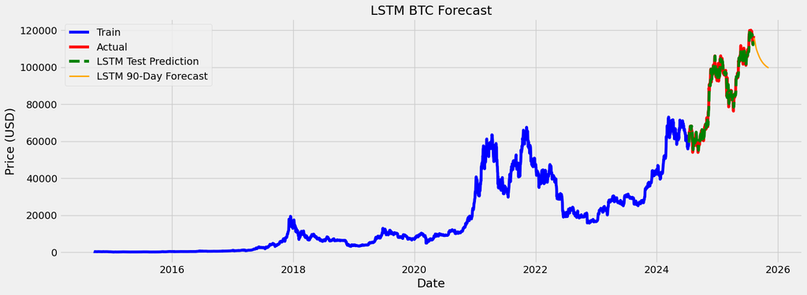

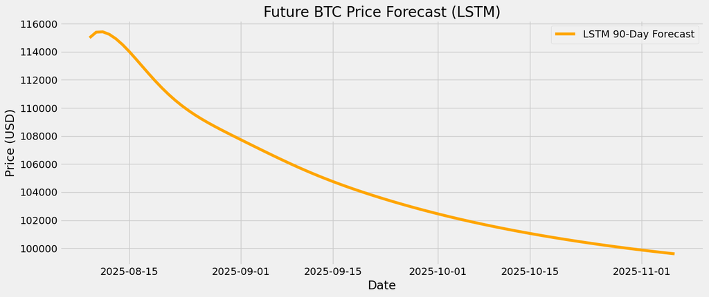

## 📌Model Observation and Conclusion :

This project applied three time series forecasting models — ARIMA, Prophet, and LSTM — to predict Bitcoin (BTC) prices. Here's a summary of the results:

[output not shown]

### 🔮 Final Takeaway

Deep learning models like LSTM offer superior adaptability and accuracy in crypto price prediction tasks, especially when compared to classical time-series models.

# ⚠️ Cautions & Limitations

These models are trained on publicly available historical data from Yahoo Finance (yfinance), and do not incorporate insider, confidential, or real-time sentiment data.

## 📉 Predictions are probabilistic, not deterministic — actual market behavior may deviate significantly due to unexpected events, regulations, or macroeconomic changes.

## 📈 For real-world trading or financial applications, it is strongly advised to incorporate high-frequency data, on-chain analytics, volume and sentiment data, and risk management strategies.

## Disclaimer:

Forecasts may NOT match actual BTC prices. These models are based only on historical closing prices from publicly available sources.

❌ No guarantee of trend accuracy — predictions may show neutral, upward, or downward movement.

❌ The models do not account for real-time factors such as:

News articles

Global economic changes

Investor sentiment

Tweets or social media influence

Whale activity or volume manipulation

❌ Not suitable for live trading decisions. This is a research and academic project only.

✅ Consider integrating NLP models with sentiment analysis for more realistic market behavior in future work.

# 📌 Real-Life Result:

#### ⚠️ Note: Crypto markets are influenced by news, regulations, and investor sentiment, which this model doesn’t currently incorporate. As such, this model provides a technical trend forecast, not an absolute price guarantee.